# 7. Spherical geometry in sf using s2geometry

Edzer Pebesma and Dewey Dunnington

**For a better version of the sf vignettes see** https://r-spatial.github.io/sf/articles/

# Introduction

This vignette describes what spherical geometry implies, and how package `sf` uses the s2geometry library (https://s2geometry.io) for geometrical measures, predicates and transformations. The code in this vignette only runs if `s2` has been installed, e.g. with

```r
install.packages("s2")
```

and is available. After `sf` has been loaded, you can check if `s2` is being used:

```r
library(sf)
sf_use_s2()
## [1] TRUE
```

Attach the `s2` package as follows:

```r
library(s2)
```

Most of the package’s functions start with `s2_` in the same way that most `sf` function names start with `st_`. Most `sf` functions automatically use `s2` functions when working with ellipsoidal coordinates; if this is not the case, e.g. for `st_voronoi()`, a warning like

```
Warning message:
In st_voronoi.sfc(st_geometry(x), st_sfc(envelope), dTolerance,  :
  st_voronoi does not correctly triangulate longitude/latitude data
```

is emitted.

# Projected and geographic coordinates

Spatial coordinates either refer to *projected* (or Cartesian) coordinates, meaning that they are associated to points on a flat space, or to unprojected or *geographic* coordinates, when they refer to angles (latitude, longitude) pointing to locations on a sphere (or ellipsoid). The flat space is also referred to as $R^2$, the sphere as $S^2$

Package `sf` implements *simple features*, a standard for point, line, and polygon geometries where geometries are built from points (nodes) connected by straight lines (edges). The simple feature standard does not say much about its suitability for dealing with geographic coordinates, but the topological relational system it builds upon ([DE9-IM](https://en.wikipedia.org/wiki/DE-9IM)) refer to $R^2$, the two-dimensional flat space.

Yet, more and more data are routinely served or exchanged using geographic coordinates. Using software that assumes an $R^2$, flat space may work for some problems, and although `sf` up to version 0.9-x had some functions in place for spherical/ellipsoidal computations (from package `lwgeom`, for computing area, length, distance, and for segmentizing), it has also happily warned the user that it is doing $R^2$, flat computations with such coordinates with messages like

```
although coordinates are longitude/latitude, st_intersects assumes that they are planar
```

hinting to the responsibility of the user to take care of potential problems. Doing this however leaves ambiguities, e.g. whether `LINESTRING(-179 0,179 0)`

- passes through `POINT(0 0)`, or
- passes through `POINT(180 0)`

and whether it is

- a straight line, cutting through the Earth’s surface, or
- a curved line following the Earth’s surface

Starting with `sf` version 1.0, if you provide a spatial object in a geographical coordinate reference system, `sf` uses the new package `s2` (Dunnington, Pebesma, Rubak 2020) for spherical geometry, which has functions for computing pretty much all measures, predicates and transformations *on the sphere*. This means:

- no more hodge-podge of some functions working on $R^2$, with annoying messages, some on the ellipsoid
- a considerable speed increase for some functions
- no computations on the ellipsoid (which are considered more accurate, but are also slower)

The `s2` package is really a wrapper around the C++ [s2geometry](https://s2geometry.io) library which was written by Google, and which is used in many of its products (e.g. Google Maps, Google Earth Engine, Bigquery GIS) and has been translated in several other programming languages.

With projected coordinates `sf` continues to work in $R^2$ as before.

# Fundamental differences

Compared to geometry on $R^2$, and DE9-IM, the `s2` package brings a few fundamentally new concepts, which are discussed first.

## Polygons on $S^2$ divide the sphere in two parts

On the sphere ($S^2$), any polygon defines two areas; when following the exterior ring, we need to define what is inside, and the definition is *the left side of the enclosing edges*. This also means that we can flip a polygon (by inverting the edge order) to obtain the other part of the globe, and that in addition to an empty polygon (the empty set) we can have the full polygon (the entire globe).

Simple feature geometries should obey a ring direction too: exterior rings should be counter clockwise, interior (hole) rings should be clockwise, but in some sense this is obsolete as the difference between exterior ring and interior rings is defined by their position (exterior, followed by zero or more interior). `sf::read_sf` has an argument `check_ring_dir` that checks, and corrects, ring directions and many (legacy) datasets have wrong ring directions. With wrong ring directions, many things still work.

For $S^2$, ring direction is essential. For that reason, `st_as_s2` has an argument `oriented = FALSE`, which will check and correct ring directions, assuming that all exterior rings occupy an area smaller than half the globe:

```r
nc = read_sf(system.file("gpkg/nc.gpkg", package="sf")) # wrong ring directions
s2_area(st_as_s2(nc, oriented = FALSE)[1:3]) # corrects ring direction, correct area:
## [1] 1137107793  610916077 1423145355
s2_area(st_as_s2(nc, oriented = TRUE)[1:3]) # wrong direction: Earth's surface minus area
## [1] 5.100649e+14 5.100655e+14 5.100646e+14
nc = read_sf(system.file("gpkg/nc.gpkg", package="sf"), check_ring_dir = TRUE)
s2_area(st_as_s2(nc, oriented = TRUE)[1:3]) # no second correction needed here:
## [1] 1137107793  610916077 1423145355
```

Here is an example where the oceans are computed as the difference from the full polygon representing the entire globe,

```r
g = as_s2_geography(TRUE)
g
## <geodesic s2_geography[1] with CRS=OGC:CRS84>
## [1] POLYGON ((0 -90, 0 -90))
```

and the countries, and shown in an orthographic projection:

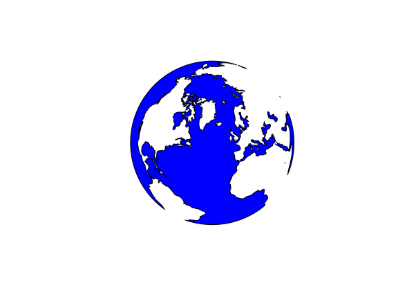

```r
co = s2_data_countries()
oc = s2_difference(g, s2_union_agg(co)) # oceans
b = s2_buffer_cells(as_s2_geography("POINT(-30 52)"), 9800000) # visible half
i = s2_intersection(b, oc) # visible ocean
plot(st_transform(st_as_sfc(i), "+proj=ortho +lat_0=52 +lon_0=-30"), col = 'blue')
```

(Note that the WKT printing of the full polygon `g` is not valid WKT, and can not be used as input as it doesn’t follow the simple feature standard; it seems to reflect the internal representation of the full polygon, and would require a WKT extension).

We can now calculate the proportion of the Earth’s surface covered by oceans:

```r
s2_area(oc) / s2_area(g)
## [1] 0.711301
```

## Semi-open polygon boundaries

Polygons in `s2geometry` can be

- CLOSED: they contain their boundaries, and a point on the boundary intersects with the polygon
- OPEN: they do not contain their boundaries, points on the boundary do not intersect with the polygon
- SEMI-OPEN: they contain part of their boundaries, but no boundary of non-overlapping polygons is contained by more than one polygon.

In principle the DE9-IM model deals with interior, boundary and exterior, and intersection predicates are sensitive to this (the difference between *contains* and *covers* is all about boundaries). DE9-IM however cannot uniquely assign points to polygons when polygons form a polygon *coverage* (no overlaps, but shared boundaries). This means that if we would count points by polygon, and some points fall *on* shared polygon boundaries, we either miss them (*contains*) or we count them double (*covers*, *intersects*); this might lead to bias and require post-processing. Using SEMI-OPEN non-overlapping polygons guarantees that every point is assigned to *maximally* one polygon in an intersection. This corresponds to e.g. how this would be handled in a grid (raster) coverage, where every grid cell (typically) only contains its upper-left corner and its upper and left sides.

```r
a = as_s2_geography("POINT(0 0)")
b = as_s2_geography("POLYGON((0 0,1 0,1 1,0 1,0 0))")
s2_intersects(a, b, s2_options(model = "open"))
## [1] FALSE
s2_intersects(a, b, s2_options(model = "closed"))
## [1] TRUE
s2_intersects(a, b, s2_options(model = "semi-open")) # a toss
## [1] FALSE
s2_intersects(a, b) # default: semi-open
## [1] FALSE
```

## Bounding cap, bounding rectangle

Computing the minimum and maximum values over coordinate ranges, as `sf` does with `st_bbox()`, is of limited value for spherical coordinates because due the the spherical space, the *area covered* is not necessarily covered by the coordinate range. Two examples:

- small regions covering the antimeridian (longitude +/- 180) end up with a huge longitude range, which doesn’t make *clear* the antimeridian is spanned
- regions including a pole will end up with a latitude range not extending to +/- 90

S2 has two alternatives: the bounding cap and the bounding rectangle:

```r
fiji = s2_data_countries("Fiji")
aa = s2_data_countries("Antarctica")
s2_bounds_cap(fiji)
##        lng       lat    angle
## 1 178.7459 -17.15444 1.801369
s2_bounds_rect(c(fiji,aa))
##     lng_lo    lat_lo    lng_hi    lat_hi
## 1  177.285 -18.28799 -179.7933 -16.02088
## 2 -180.000 -90.00000  180.0000 -63.27066
```

The cap reports a bounding cap (circle) as a mid point (lat, lng) and an angle around this point. The bounding rectangle reports the `_lo` and `_hi` bounds of `lat` and `lng` coordinates. Note that for Fiji, `lng_lo` being higher than `lng_hi` indicates that the region covers (crosses) the antimeridian.

# Switching between S2 and GEOS

The two-dimensional $R^2$ library that was formerly used by `sf` is [GEOS](https://libgeos.org), and `sf` can be instrumented to use GEOS or `s2`. First we will ask if `s2` is being used by default:

```r
sf_use_s2()
## [1] TRUE
```

then we can switch it off (and use GEOS) by

```r
sf_use_s2(FALSE)
## Spherical geometry (s2) switched off
```

and switch it on (and use s2) by

```r
sf_use_s2(TRUE)
## Spherical geometry (s2) switched on
```

# Measures

## Area

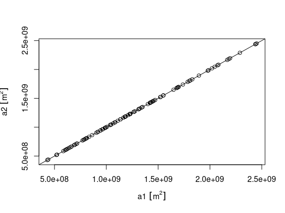

```r
library(sf)
library(units)
## udunits database from /usr/share/xml/udunits/udunits2.xml
nc = read_sf(system.file("gpkg/nc.gpkg", package="sf"))
sf_use_s2(TRUE)
a1 = st_area(nc)
sf_use_s2(FALSE)
## Spherical geometry (s2) switched off
a2 = st_area(nc)
plot(a1, a2)
abline(0, 1)
```

```r
summary((a1 - a2)/a1)
##       Min.    1st Qu.     Median       Mean    3rd Qu.       Max.
## -2.638e-04 -1.650e-04 -7.133e-05 -6.448e-05  1.598e-05  2.817e-04
```

## Length

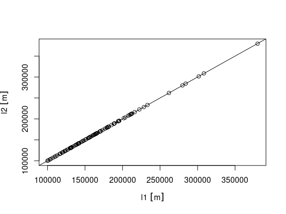

```r
nc_ls = st_cast(nc, "MULTILINESTRING")
sf_use_s2(TRUE)
## Spherical geometry (s2) switched on
l1 = st_length(nc_ls)
sf_use_s2(FALSE)
## Spherical geometry (s2) switched off
l2 = st_length(nc_ls)
plot(l1 , l2)
abline(0, 1)
```

```r
summary((l1-l2)/l1)
##       Min.    1st Qu.     Median       Mean    3rd Qu.       Max.
## -0.0012301 -0.0004396 -0.0001258 -0.0001123  0.0001742  0.0009660
```

## Distances

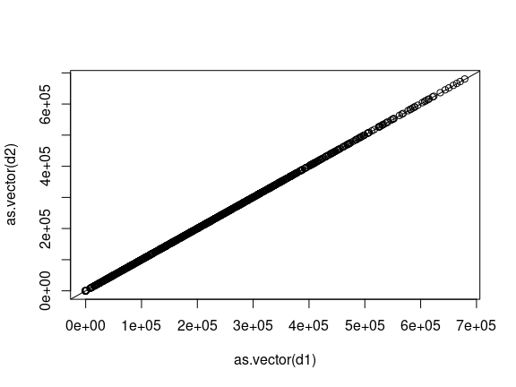

```r
sf_use_s2(TRUE)
## Spherical geometry (s2) switched on
d1 = st_distance(nc, nc[1:10,])
sf_use_s2(FALSE)
## Spherical geometry (s2) switched off
d2 = st_distance(nc, nc[1:10,])
plot(as.vector(d1), as.vector(d2))
abline(0, 1)
```

```r
summary(as.vector(d1)-as.vector(d2))
##    Min. 1st Qu.  Median    Mean 3rd Qu.    Max.
## -1424.5  -613.2  -236.5  -319.5     0.0   460.1
```

# Predicates

All unary and binary predicates are available in `s2`, except for `st_relate` with a pattern. In addition, when using the `s2` predicates, depending on the `model`, intersections with neighbours are only reported when `model` is `closed` (the default):

```r
sf_use_s2(TRUE)
## Spherical geometry (s2) switched on
st_intersects(nc[1:3,], nc[1:3,]) # self-intersections + neighbours
## Sparse geometry binary predicate list of length 3, where the predicate
## was `intersects'
##  1: 1, 2
##  2: 1, 2, 3
##  3: 2, 3
sf_use_s2(TRUE)
st_intersects(nc[1:3,], nc[1:3,], model = "semi-open") # only self-intersections
## Sparse geometry binary predicate list of length 3, where the predicate
## was `intersects'
##  1: 1
##  2: 2
##  3: 3
```

# Transformations

`st_intersection`, `st_union`, `st_difference` and `st_sym_difference` are available as `s2` equivalents. N-ary intersection and difference are not (yet) present; cascaded union is present; unioning by feature does not work with `s2`.

## Buffers

Buffers can be calculated for features with geographic coordinates as follows, using an unprojected object representing the UK as an example:

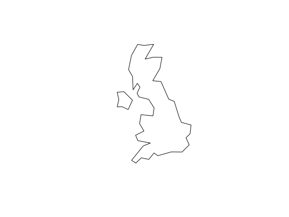

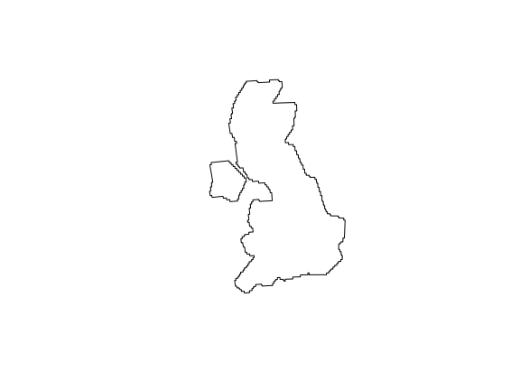

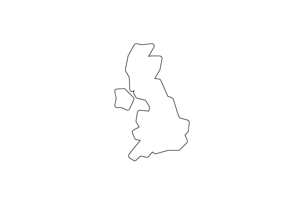

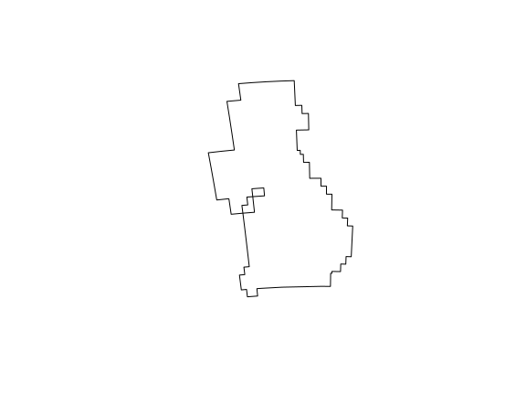

```r
uk = s2_data_countries("United Kingdom")
class(uk)
## [1] "s2_geography" "wk_vctr"
uk_sfc = st_as_sfc(uk)
uk_buffer = s2_buffer_cells(uk, distance = 20000)
uk_buffer2 = s2_buffer_cells(uk, distance = 20000, max_cells = 10000)
uk_buffer3 = s2_buffer_cells(uk, distance = 20000, max_cells = 100)
class(uk_buffer)
## [1] "s2_geography" "wk_vctr"
plot(uk_sfc)
plot(st_as_sfc(uk_buffer))
plot(st_as_sfc(uk_buffer2))
plot(st_as_sfc(uk_buffer3))
uk_sf = st_as_sf(uk)
```

The plots above show that you can adjust the level of spatial precision in the results of s2 buffer operations with the `max_cells` argument, set to 1000 by default. Deciding on an appropriate value is a balance between excessive detail increasing computational resources (represented by `uk_buffer2`, bottom left) and excessive simplification (bottom right). Note that buffers created with s2 *always* follow s2 cell boundaries, they are never smooth. Hence, choosing a large number for `max_cells` leads to seemingly smooth but, zoomed in, very complex buffers.

To achieve a similar result you could first transform the result and then use the `st_buffer()` function from `sf`. A simple benchmark shows the computational efficiency of the `s2` geometry engine in comparison with transforming and then creating buffers:

```r
# the sf way
system.time({
  uk_projected = st_transform(uk_sfc, 27700)
  uk_buffer_sf = st_buffer(uk_projected, dist = 20000)
})
##    user  system elapsed
##   0.040   0.000   0.039
# sf way with few than the 30 segments in the buffer
system.time({
  uk_projected = st_transform(uk_sfc, 27700)
  uk_buffer_sf2 = st_buffer(uk_projected, dist = 20000, nQuadSegs = 4)
})
##    user  system elapsed
##   0.025   0.000   0.025
# s2 with default cell size
system.time({
  uk_buffer = s2_buffer_cells(uk, distance = 20000)
})
##    user  system elapsed
##   0.036   0.000   0.035
# s2 with 10000 cells
system.time({
  uk_buffer2 = s2_buffer_cells(uk, distance = 20000, max_cells = 10000)
})
##    user  system elapsed
##   0.264   0.000   0.264
# s2 with 100 cells
system.time({
  uk_buffer2 = s2_buffer_cells(uk, distance = 20000, max_cells = 100)
})
##    user  system elapsed
##   0.005   0.000   0.005
```

The result of the previous benchmarks emphasise the point that there are trade-offs between geographic resolution and computational resources, something that web developers working on geographic services such as Google Maps understand well. In this case the default setting of 1000 cells, which runs slightly faster than the default transform -> buffer workflow, is probably appropriate given the low resolution of the input geometry representing the UK.

## `st_buffer` or `st_is_within_distance`?

As discussed in the [`sf` issue tracker](https://github.com/r-spatial/sf/issues/1367), deciding on workflows and selecting appropriate levels of level of geographic resolution can be an iterative process. `st_buffer` as powered by GEOS, for $R^2$ data, are smooth and (nearly) exact. `st_buffer` as powered by $S^2$ is rougher, complex, non-smooth, and may need tuning. An common pattern where `st_buffer` is used is this:

- compute buffers around a set of features `x` (points, lines, polygons)
- within each of these buffers, find all occurances of some other spatial variable `y` and aggregate them (e.g. count points, or average a raster variable like precipitation or population density)
- work with these aggregated values (discard the buffer)

When this is the case, and you are working with geographic coordinates, it may pay off to *not* compute buffers, but instead directly work with `st_is_within_distance` to select, for each feature of `x`, all features of `y` that are within a certain distance `d` from `x`. The $S^2$ version of this function uses spatial indexes, so is fast for large datasets.

## References

- Dewey Dunnington, Edzer Pebesma and Ege Rubak, 2020. s2: Spherical Geometry Operators Using the $S^2$ Geometry Library. https://r-spatial.github.io/s2/, https://github.com/r-spatial/s2